# advanced_sr

Lara Puhlmann (Papoula Petri-Romão for Part A: basic sr section)

2024-08-29

Note: this is the advanced sr script.

For your convenience, the “basic_sr” script is included here again, as it forms the basis for the advanced calculations.

To start with the advanced calculations, you can run all code up to “Part B”.

We have processed the data set to be a bit easier to work with for the purpose of this workshop, but the data remains the same.

You will find the ressymp_workshop data on our github.

You will have calculated the necessary variables that form the basis for this advanced script from the “basic_sr” script

```r
ds <- read_csv("ressymp_workshop.csv")
```

```
## ──────────────────────────────────────────────────────── Delimiter: "," chr
## (8): language.ID, risk.group, quarantine.status, diagnosed.mental.heal... dbl
## (183): ...1, ...2, subject.ID, questionnaire.ID, beep, start.Date, respo... lgl
## (5): CE_30, PAS_all, PAS_state, PAS_T0, O_corona
```

# Basic SR score

The “Stressor Reactivity” is the reaction as expressed in mental health problems (P) to stressors (E). Therefore you need to identify the stressor exposure measures (E) and measures of mental health problems/symptoms in your dataset (P).

## 1 Identify your E and P

In Dynacore-L we have two types of stressors, Corona-related stressors and General stressors.

- CE : Corona-related stressors, 29 items; 0-5, 0= did not happen.
- GE : General stressors, 11 items; 0-5, 0= did not happen.

CE_30 and GE_12 are open questions and are not used for this scoring.

```
  Task 1a: Find stressor items in the dataset and look at this subset. Check that the range of the items is as expected.
```

```r
# there are many acceptable solutions, this is the dplyr way
ds %>%
  dplyr::select(
    starts_with(
      c("GE_", "CE_")
      )
    ) %>%
  # head returns the first 10 columns of the subset
  head
```

```
## # A tibble: 6 × 42
##   GE_01 GE_02 GE_03 GE_04 GE_05 GE_06 GE_07 GE_08 GE_09 GE_10 GE_11 GE_12 CE_01
##   <dbl> <dbl> <dbl> <dbl> <dbl> <dbl> <dbl> <dbl> <dbl> <dbl> <dbl> <dbl> <dbl>
## 1     1     0     0     0     1     1     0     0     0     0     0     1     0
## 2     1     0     0     0     0     1     0     0     0     0     0    NA     0
## 3     1     0     0     0     0     0     0     0     0     0     0    NA     0
## 4     0     0     0     0     0     0     0     0     0     0     0    NA     0
## 5     1     0     0     0     0     0     0     0     0     0     0    NA     0
## 6     3     3     0     0     0     0     0     0     0     4     0    NA     0
## # ℹ 29 more variables: CE_02 <dbl>, CE_03 <dbl>, CE_04 <dbl>, CE_05 <dbl>,
## #   CE_06 <dbl>, CE_07 <dbl>, CE_08 <dbl>, CE_09 <dbl>, CE_10 <dbl>,
## #   CE_11 <dbl>, CE_12 <dbl>, CE_13 <dbl>, CE_14 <dbl>, CE_15 <dbl>,
## #   CE_16 <dbl>, CE_17 <dbl>, CE_18 <dbl>, CE_19 <dbl>, CE_20 <dbl>,
## #   CE_21 <dbl>, CE_22 <dbl>, CE_23 <dbl>, CE_24 <dbl>, CE_25 <dbl>,
## #   CE_26 <dbl>, CE_27 <dbl>, CE_28 <dbl>, CE_29 <dbl>, CE_30 <lgl>
```

```r
# summary return min, max, quartiles, median and mean
ds %>%
  dplyr::select(starts_with(c("GE_", "CE_"))) %>%
  summary()
```

```
##      GE_01           GE_02           GE_03           GE_04          GE_05
##  Min.   :0.000   Min.   :0.000   Min.   :0.000   Min.   :0.00   Min.   :0.000
##  1st Qu.:1.000   1st Qu.:0.000   1st Qu.:0.000   1st Qu.:0.00   1st Qu.:0.000
##  Median :3.000   Median :2.000   Median :0.000   Median :0.00   Median :1.000
##  Mean   :2.368   Mean   :1.821   Mean   :1.019   Mean   :1.18   Mean   :1.662
##  3rd Qu.:3.000   3rd Qu.:3.000   3rd Qu.:2.000   3rd Qu.:3.00   3rd Qu.:3.000
##  Max.   :5.000   Max.   :5.000   Max.   :5.000   Max.   :5.00   Max.   :5.000
##
##      GE_06           GE_07           GE_08            GE_09
##  Min.   :0.000   Min.   :0.000   Min.   :0.0000   Min.   :0.0000
##  1st Qu.:0.000   1st Qu.:0.000   1st Qu.:0.0000   1st Qu.:0.0000
##  Median :0.000   Median :2.000   Median :0.0000   Median :0.0000
##  Mean   :0.822   Mean   :2.007   Mean   :0.9579   Mean   :0.2756
##  3rd Qu.:2.000   3rd Qu.:3.000   3rd Qu.:2.0000   3rd Qu.:0.0000
##  Max.   :5.000   Max.   :5.000   Max.   :5.0000   Max.   :5.0000
##
##      GE_10           GE_11            GE_12         CE_01
##  Min.   :0.000   Min.   :0.0000   Min.   :1     Min.   :0.0000
##  1st Qu.:0.000   1st Qu.:0.0000   1st Qu.:1     1st Qu.:0.0000
##  Median :0.000   Median :0.0000   Median :1     Median :0.0000
##  Mean   :0.777   Mean   :0.1426   Mean   :1     Mean   :0.4842
##  3rd Qu.:0.000   3rd Qu.:0.0000   3rd Qu.:1     3rd Qu.:0.0000
##  Max.   :5.000   Max.   :5.0000   Max.   :1     Max.   :5.0000
##                                   NA's   :915
##      CE_02            CE_03           CE_04            CE_05
##  Min.   :0.0000   Min.   :0.000   Min.   :0.0000   Min.   :0.000
##  1st Qu.:0.0000   1st Qu.:0.000   1st Qu.:0.0000   1st Qu.:0.000
##  Median :0.0000   Median :0.000   Median :0.0000   Median :2.000
##  Mean   :0.5512   Mean   :1.063   Mean   :0.7129   Mean   :1.894
##  3rd Qu.:0.0000   3rd Qu.:2.000   3rd Qu.:1.0000   3rd Qu.:3.000
##  Max.   :5.0000   Max.   :5.000   Max.   :5.0000   Max.   :5.000
##
##      CE_06            CE_07            CE_08           CE_09
##  Min.   :0.0000   Min.   :0.0000   Min.   :0.000   Min.   :0.000
##  1st Qu.:0.0000   1st Qu.:0.0000   1st Qu.:0.000   1st Qu.:1.000
##  Median :0.0000   Median :0.0000   Median :1.000   Median :3.000
##  Mean   :0.6268   Mean   :0.1665   Mean   :1.625   Mean   :2.499
##  3rd Qu.:0.0000   3rd Qu.:0.0000   3rd Qu.:3.000   3rd Qu.:4.000
##  Max.   :5.0000   Max.   :5.0000   Max.   :5.000   Max.   :5.000
##
```

[output cut: 33 more lines]

```
##  Min.   :0.0000   Min.   :0.0000   Min.   :0.0000   Min.   :0.000
##  1st Qu.:0.0000   1st Qu.:0.0000   1st Qu.:0.0000   1st Qu.:2.000
##  Median :0.0000   Median :0.0000   Median :0.0000   Median :3.000
##  Mean   :0.4096   Mean   :0.6077   Mean   :0.7876   Mean   :2.551
##  3rd Qu.:0.0000   3rd Qu.:1.0000   3rd Qu.:2.0000   3rd Qu.:3.000
##  Max.   :5.0000   Max.   :5.0000   Max.   :5.0000   Max.   :5.000
##
##   CE_30
##  Mode:logical
##  NA's:1045
##
##
##
##
##
```

As P we have the GHQ (CM in the dataset).

CM : 0-3, where 0 is did not happen.

```
  Task 1b: Find mental health items in the dataset and look at this subset. Check that the range of the items is expected.
```

```r
# there are many acceptable solutions, this is the dplyr way
ds %>%
  dplyr::select(
    starts_with("CM")
  ) %>%
  # head returns the first 10 columns of the subset
  head
```

```
## # A tibble: 6 × 12
##   CM_01 CM_02 CM_03 CM_04 CM_05 CM_06 CM_07 CM_08 CM_09 CM_10 CM_11 CM_12
##   <dbl> <dbl> <dbl> <dbl> <dbl> <dbl> <dbl> <dbl> <dbl> <dbl> <dbl> <dbl>
## 1     0     0     1     1     1     1     0     1     1     0     0     0
## 2     0     0     1     1     1     1     0     1     1     0     0     0
## 3     0     0     1     1     1     1     0     1     1     0     0     0
## 4     0     0     1     1     1     1     1     1     1     1     1     0
## 5     0     0     1     1     1     1     0     1     1     0     0     0
## 6     1     1     2     1     1     2     0     2     1     1     0     0
```

```r
ds %>%
  dplyr::select(
    starts_with("CM")
  ) %>%
  # summary returns min, max, quartiles, median and mean
  summary()
```

```
##      CM_01            CM_02           CM_03           CM_04
##  Min.   :0.0000   Min.   :0.000   Min.   :0.000   Min.   :0.000
##  1st Qu.:0.0000   1st Qu.:1.000   1st Qu.:1.000   1st Qu.:1.000
##  Median :1.0000   Median :1.000   Median :1.000   Median :1.000
##  Mean   :0.9694   Mean   :1.252   Mean   :1.459   Mean   :1.292
##  3rd Qu.:2.0000   3rd Qu.:2.000   3rd Qu.:2.000   3rd Qu.:2.000
##  Max.   :3.0000   Max.   :3.000   Max.   :3.000   Max.   :3.000
##      CM_05           CM_06           CM_07           CM_08
##  Min.   :0.000   Min.   :0.000   Min.   :0.000   Min.   :0.000
##  1st Qu.:1.000   1st Qu.:1.000   1st Qu.:1.000   1st Qu.:1.000
##  Median :1.000   Median :1.000   Median :1.000   Median :1.000
##  Mean   :1.053   Mean   :1.261   Mean   :1.139   Mean   :1.392
##  3rd Qu.:1.000   3rd Qu.:2.000   3rd Qu.:2.000   3rd Qu.:2.000
##  Max.   :3.000   Max.   :3.000   Max.   :3.000   Max.   :3.000
##      CM_09           CM_10           CM_11           CM_12
##  Min.   :0.000   Min.   :0.000   Min.   :0.000   Min.   :0.0000
##  1st Qu.:1.000   1st Qu.:1.000   1st Qu.:0.000   1st Qu.:0.0000
##  Median :1.000   Median :1.000   Median :1.000   Median :1.0000
##  Mean   :1.418   Mean   :1.281   Mean   :1.049   Mean   :0.7866
##  3rd Qu.:2.000   3rd Qu.:2.000   3rd Qu.:2.000   3rd Qu.:1.0000
##  Max.   :3.000   Max.   :3.000   Max.   :3.000   Max.   :3.0000
```

### 1.1 building sum scores

#### 1.1.1 P

Score your P according to the manual. For GHQ this is a sum score of all items.

```
  Task 1.1.1a: Calculate the sum score of GHQ (P)
```

```r
ds <- ds %>%
  # mutate allows us to create a new variable
  dplyr::mutate(
    # we name this new variable P & calculate the Sum per row
    P=base::rowSums(
      # with across we specify what columns are summed
      across(c(CM_01:CM_12)),
      # here we specify that if there is an NA value it is removed
      na.rm = T)
                )
```

#### 1.1.2 E

Dependent on your data set you might have different considerations on how you will build your E sum score.

If you have different type of stressors within the same data set, for example, life events and daily hassles, or general and pandemic stressors, you will in most cases want to built separate sum scores for each type of stressor first.

```
  Task 1.1.2a: Create two sum scores, one for the general stressors (Eg), one for the corona-related stressors (Ec).
```

```r
ds <- ds %>%
  # mutate allows us to create a new variable
  dplyr::mutate(
    # we name this new variable Eg & calculate the Sum per row
    Eg=base::rowSums(
      # with across we specify what columns are summed
      across(c(GE_01:GE_11)),
      # here we specify that if there is an NA value it is removed
      na.rm = T),
    # now we calculate a separate E for the pandemic stressors
    Ec=base::rowSums(
      # with across we specify what columns are summed
      across(c(CE_01:CE_29)),
      # here we specify that if there is an NA value it is removed
      na.rm = T)
                )
```

#### 1.1.3 to scale or not to scale?

Now the question is how could one combine the E scores. Usually, you want to built the SR score based on the most information available, meaning all types of available stressors. There are two options: you could simply sum all items)

1. you could sum all items. This works when all stressors are measured or coded the same way (for example all of them indicate occurrence). This would mean that if the type of stressors are not equally represented, the one type for which there are more items will be weighted more. In our example, there are more CE (29 items) then general stressors (11 items).
2. you could create a mean of the scaled sum scores. this would allow both type of stressors to be equally weighted. This is the approach we have used in MARP and LORA which is described in the [FRESHMO paper](https://www.frontiersin.org/articles/10.3389/fpsyg.2021.710493).

   Task 1.1.3: create a scaled combined E score (E_scaled)

```r
ds <- ds  %>%
  ungroup %>%
  # here we are scaling across all time points and all participants
  mutate(Eg_scaled= scale(Eg),
         Ec_scaled=scale(Ec)) %>%
dplyr::group_by(subject.ID) %>%
  # because we are creating the mean by rows and not by column
  rowwise() %>%
  dplyr::mutate(E_scaled=mean(c(Eg_scaled,Ec_scaled),na.rm = T))%>%
  # this is important to make revert the rowwise operator
  ungroup %>%
  dplyr::group_by(subject.ID)
```

#### 1.1.4 per timepoint/over time periods

SR is expected to be quite stable and change over longer periods of times. That is a sudden or short change in SR is usually not indicative of less resilient outcomes, rather it is the SR over longer time periods that is more informative on the resilience of participants. Consequently, in longitudinal studies we are often interested in longer time periods rather than single time points. For example in the longitudinal samples MARP and LORA we look at period of 9 months to ca. 3.5 years [see Petri-Romão et al.](https://osf.io/dgx4k). For this purpose we create the mean stressor exposure and mean P in the time period of interest.

```
  Task 1.1.4a: Create mean E scores (Eg_t1.t6, Ec_t1.t6) across all timepoints
```

```r
ds <- ds %>%
  group_by(subject.ID) %>%
  mutate(
    Eg_t1.t6 = base::mean(
      # we mean the already calculated sum score
      Eg,
      # here we specify that if there is an NA value it is removed
      na.rm = T),
    # now we calculate a separate E for the pandemic stressors
    Ec_t1.t6 =base::mean(
      Ec,
      # here we specify that if there is an NA value it is removed
      na.rm = T)
  )
```

```
  Task 1.1.4b: Create mean P scores (P_t1.t6) across all timepoints
```

```r
ds <- ds %>%
  group_by(subject.ID) %>%
  mutate(
    P_t1.t6 = base::mean(
      # we mean the already calculated sum score
      P,
      # here we specify that if there is an NA value it is removed
      na.rm = T)
  )
```

In the case of the combined E score the order of operations is as follows

1. create mean sum scores for each time period (separately for Eg, Ec)
2. scale each separate sum score. This means we are scaling over the time period of interest
3. create combined mean score of the scaled scores

   Task 1.1.4c: Create combined E scores over the whole time period E_t1.t6, E_t1.t6_scaled

```r
ds <- ds %>%
  group_by(subject.ID) %>%
  # first we create a mean of the simple combined sum score
  mutate(E_t1.t6 = base::mean(E, na.rm=TRUE)) %>%
    ungroup() %>%
  # now we create an equally weighted E mean score over t1 to t6
  mutate(
    Eg_t1.t6_scaled = scale(
      # we mean the already calculated sum score (see previous chunk)
      Eg_t1.t6),
    # now we calculate a separate E for the pandemic stressors
    Ec_t1.t6_scaled = scale(
      Ec_t1.t6)
  ) %>%
  # now we create a combined mean score
  group_by(subject.ID) %>%
  mutate(
    E_t1.t6_scaled = base::mean(c(Eg_t1.t6_scaled, Ec_t1.t6_scaled), na.rm=TRUE)
  )
```

### 1.2 first look into E and P

First we check that our scores are reasonable. Plotting and summarising the scores makes sense to check that you have done everything correctly and give you a sense if there are outliers. We will not look into the treatment of outliers now, but as good practice you should get used to plotting and checking your data.

```
  Task 1.2a: Describe the scores
  Generate descriptive statistics of the scores you build to check their quality. (e.g. mean, median, min, max)
  EXTRA: plot the scores. (e.g. scatter, histogram, boxplot...)

  Task 1.2b: Interpret your results
  * did you do everything correctly?
  * do you think there are outliers?
```

```r
# skimr::skim offers a quick look into each variable
ds %>%
  ungroup() %>%
  # select the variables you want to look at
  select(E,E_scaled, Ec, Eg, E_t1.t6, Ec_t1.t6, Eg_t1.t6,E_t1.t6_scaled, Ec_t1.t6_scaled, Eg_t1.t6_scaled, P) %>%
  skimr::skim()
```

Data summary

| Name | Piped data |
| --- | --- |
| Number of rows | 1045 |
| Number of columns | 11 |
| _______________________ |  |
| Column type frequency: |  |
| numeric | 11 |
| ________________________ |  |
| Group variables | None |

**Variable type: numeric**

| skim_variable | n_missing | complete_rate | mean | sd | p0 | p25 | p50 | p75 | p100 | hist |
| --- | --- | --- | --- | --- | --- | --- | --- | --- | --- | --- |
| E | 0 | 1 | 43.90 | 20.51 | 0.00 | 29.00 | 41.00 | 57.00 | 109.00 | ▂▇▆▂▁ |
| E_scaled | 0 | 1 | 0.00 | 0.87 | -1.85 | -0.65 | -0.10 | 0.58 | 2.77 | ▂▇▆▂▁ |
| Ec | 0 | 1 | 30.86 | 15.58 | 0.00 | 20.00 | 28.00 | 41.00 | 89.00 | ▃▇▅▂▁ |
| Eg | 0 | 1 | 13.03 | 7.58 | 0.00 | 7.00 | 12.00 | 18.00 | 42.00 | ▆▇▅▁▁ |
| E_t1.t6 | 0 | 1 | 43.90 | 0.00 | 43.90 | 43.90 | 43.90 | 43.90 | 43.90 | ▁▁▇▁▁ |
| Ec_t1.t6 | 0 | 1 | 30.86 | 0.00 | 30.86 | 30.86 | 30.86 | 30.86 | 30.86 | ▁▁▇▁▁ |
| Eg_t1.t6 | 0 | 1 | 13.03 | 0.00 | 13.03 | 13.03 | 13.03 | 13.03 | 13.03 | ▁▁▇▁▁ |
| E_t1.t6_scaled | 1045 | 0 | NaN | NA | NA | NA | NA | NA | NA |  |
| Ec_t1.t6_scaled | 1045 | 0 | NaN | NA | NA | NA | NA | NA | NA |  |
| Eg_t1.t6_scaled | 1045 | 0 | NaN | NA | NA | NA | NA | NA | NA |  |
| P | 0 | 1 | 14.35 | 5.90 | 2.00 | 10.00 | 13.00 | 18.00 | 34.00 | ▃▇▆▂▁ |

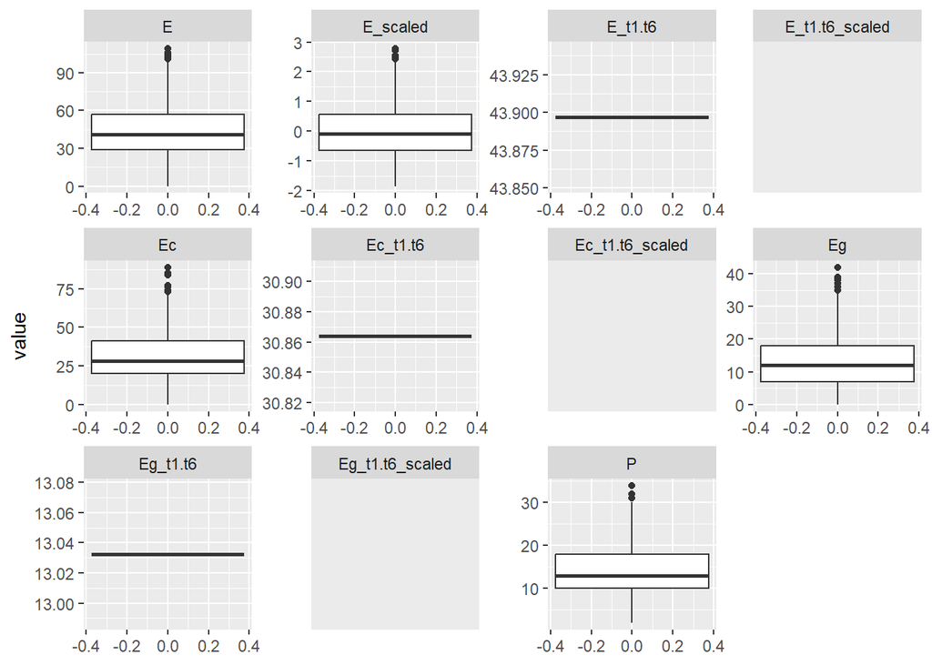

```r
## Plotting ###

ds %>%
  group_by(subject.ID) %>%
  select(subject.ID,E,E_scaled, Ec, Eg, E_t1.t6, Ec_t1.t6, Eg_t1.t6,E_t1.t6_scaled, Ec_t1.t6_scaled, Eg_t1.t6_scaled, P) %>%
  # we need to reformat the dataset for easier plotting in ggplot, but you can also skip this if you want to plot them separately
  pivot_longer(-subject.ID) %>%
  # plotting happens here
  ggplot(aes(y=value))+
  # we choose the kind of plot
  geom_boxplot()+
  # this creates separate plot for each variable. scales=free adjusts the axes for each plot individually
  facet_wrap(~name, scales = "free")
```

### 1.3 Choosing E

We want to choose an E score based on a robust (that is high and interpretable) relationship with P.

```
  Task 1.3a: Calculate the correlations between E an P
  Calculate them between all scores or just one, depending on your knowledge of coding.
  EXTRA: plot the correlation matrix for easy interpretation.

  Task 1.3b: Interpret the scores
  * which E score has the highest correlation with P?
  * what do the separate E scores' correlations tell you about their influence on P? (is Eg or Ec more important)
  * does the scaling have an impact on the relationship?
  * what could be a reason to choose separate scores rather than combined scores?
  * which E score would you use?
```

```r
# here we just calculate all the different correlations
ds %>%
  ungroup() %>%
  select(E,E_scaled, Ec, Eg, P) %>%
  cor(., use="pairwise.complete.obs")
```

```
##                  E  E_scaled        Ec        Eg         P
## E        1.0000000 0.9811623 0.9482135 0.7570254 0.4922965
## E_scaled 0.9811623 1.0000000 0.8689892 0.8689892 0.5194342
## Ec       0.9482135 0.8689892 1.0000000 0.5102845 0.4069348
## Eg       0.7570254 0.8689892 0.5102845 1.0000000 0.4958306
## P        0.4922965 0.5194342 0.4069348 0.4958306 1.0000000
```

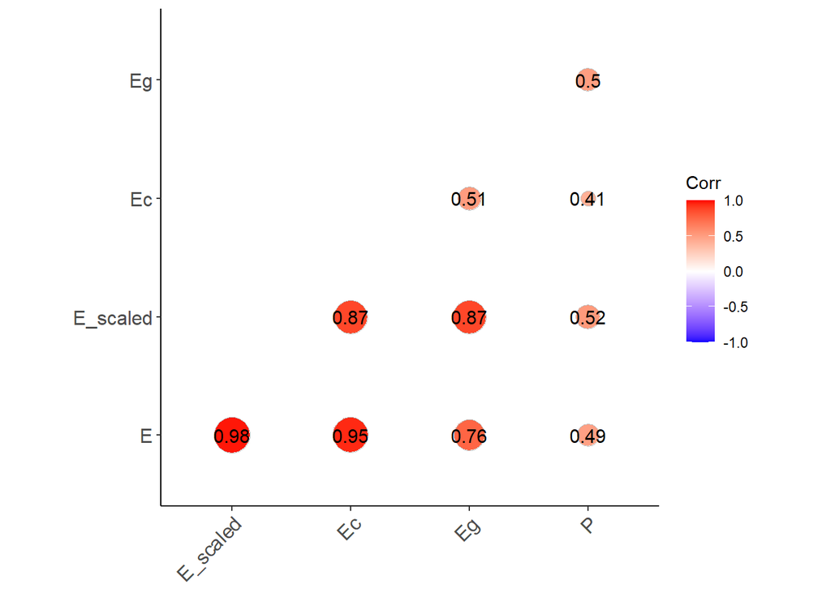

```r
# here we plot the correlations with ggcorrplot
ds %>%
  ungroup() %>%
  select(E,E_scaled, Ec, Eg, P) %>%
  cor(., use="pairwise.complete.obs")%>%
  ggcorrplot::ggcorrplot(
                          show.legend = TRUE, type="lower", method = "circle", lab=TRUE,
                          ggtheme = ggplot2::theme_classic)
```

```r
# here we calculate the correlations of the average E and P in t1-t6
ds %>%
  ungroup() %>%
  select(E_t1.t6, Ec_t1.t6, Eg_t1.t6,E_t1.t6_scaled, P_t1.t6) %>%
  cor(., use="pairwise.complete.obs")
```

```
##                E_t1.t6 Ec_t1.t6 Eg_t1.t6 E_t1.t6_scaled P_t1.t6
## E_t1.t6             NA       NA       NA             NA      NA
## Ec_t1.t6            NA       NA       NA             NA      NA
## Eg_t1.t6            NA       NA       NA             NA      NA
## E_t1.t6_scaled      NA       NA       NA             NA      NA
## P_t1.t6             NA       NA       NA             NA      NA
```

[figure not shown]

```r
# here we plot again
ds %>%
  ungroup() %>%
  select(E_t1.t6, Ec_t1.t6, Eg_t1.t6,E_t1.t6_scaled, P_t1.t6)%>%
  stats::cor(., use = "pairwise.complete.obs") %>%
  ggcorrplot::ggcorrplot(
                          show.legend = TRUE, type="lower", method = "circle", lab=TRUE,
                          ggtheme = ggplot2::theme_classic)
```